# Suggested solutions for exercises, week 1

Martin Johnsson

17 januari 2017

The ggplot2 package will be needed for the plots:

```r
library(ggplot2)
```

# 1

Assuming that the text file is stored in the current R working directory:

```r
mens_long_jump_records <- read.csv("mens_long_jump_records.txt",
                                   stringsAsFactors = FALSE,
                                   comment.char = "#")
```

We first create the plot, give it a name, and call it to print:

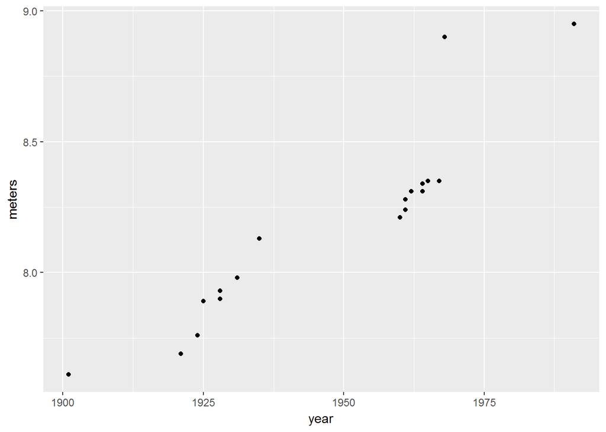

```r
records_plot_dots <- qplot(x = year, y = meters, data = mens_long_jump_records)
records_plot_dots
```

Let’s try a different geom:

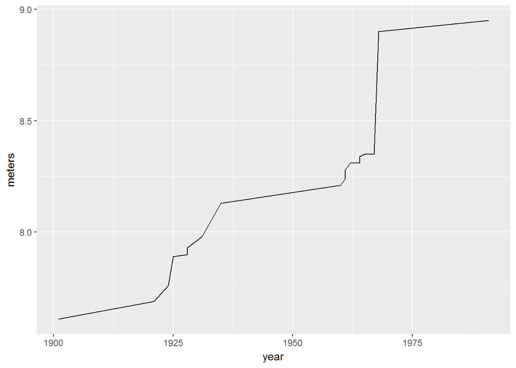

```r
records_plot_lines <- qplot(x = year, y = meters, data = mens_long_jump_records,
                            geom = "line")
records_plot_lines
```

# 2

We fit the model:

```r
model <- lm(meters ~ year, data = mens_long_jump_records)
```

Then investigate it:

```r
model
```

```
##
## Call:
## lm(formula = meters ~ year, data = mens_long_jump_records)
##
## Coefficients:
## (Intercept)         year
##   -19.60871      0.01427
```

There are several functions to pull out parts of the result:

```r
summary(model)
```

```
##
## Call:
## lm(formula = meters ~ year, data = mens_long_jump_records)
##
## Residuals:
##      Min       1Q   Median       3Q      Max
## -0.14141 -0.09528 -0.06921  0.04118  0.43446
##
## Coefficients:
##               Estimate Std. Error t value Pr(>|t|)
## (Intercept) -19.608713   2.935192  -6.681 5.28e-06 ***
## year          0.014265   0.001507   9.466 5.86e-08 ***
## ---
## Signif. codes:  0 '***' 0.001 '**' 0.01 '*' 0.05 '.' 0.1 ' ' 1
##
## Residual standard error: 0.146 on 16 degrees of freedom
## Multiple R-squared:  0.8485, Adjusted R-squared:  0.839
## F-statistic: 89.61 on 1 and 16 DF,  p-value: 5.862e-08
```

```r
coef(model)
```

```
##  (Intercept)         year
## -19.60871339   0.01426537
```

```r
confint(model)
```

```
##                    2.5 %       97.5 %
## (Intercept) -25.83104228 -13.38638451
## year          0.01107065   0.01746009
```

We can use the coefficients to interpolate. The first coefficient is the constant term, the intercept.

The second is the coefficient associated with year, i.e. is the slope.

To get the prediction for 1950, we use the equation for a line:

```r
coef(model)[1] + 1950 * coef(model)[2]
```

```
## (Intercept)
##     8.20876
```

# 3

Here is an alternative way to write the model:

```r
model_recoded <- lm(meters ~ I(year - 1900), data = mens_long_jump_records)
coef(model_recoded)
```

```
##    (Intercept) I(year - 1900)
##     7.49549125     0.01426537
```

Now, to get the prediction for 1950:

```r
coef(model_recoded)[1] + (1950 - 1900) * coef(model_recoded)[2]
```

```
## (Intercept)
##     8.20876
```

# 4

seq will give us a sequence of numbers with some given spacing.

```r
seq(from = 1, to = 100, by = 2)
```

```
##  [1]  1  3  5  7  9 11 13 15 17 19 21 23 25 27 29 31 33 35 37 39 41 43 45
## [24] 47 49 51 53 55 57 59 61 63 65 67 69 71 73 75 77 79 81 83 85 87 89 91
## [47] 93 95 97 99
```

# 5

```r
x <- seq(from = 0, to = 2 * pi, by = 0.1)
```

We have our sequence. Now we apply the functions:

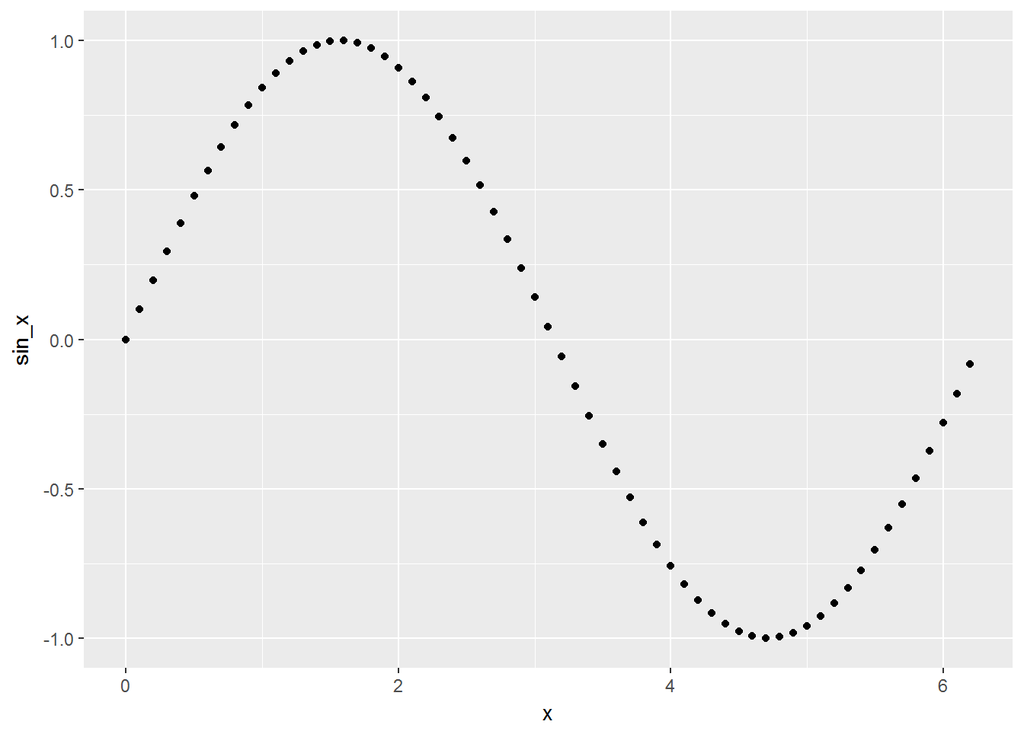

```r
sin_x <- sin(x)
sine_plot <- qplot(x, sin_x)
sine_plot
```

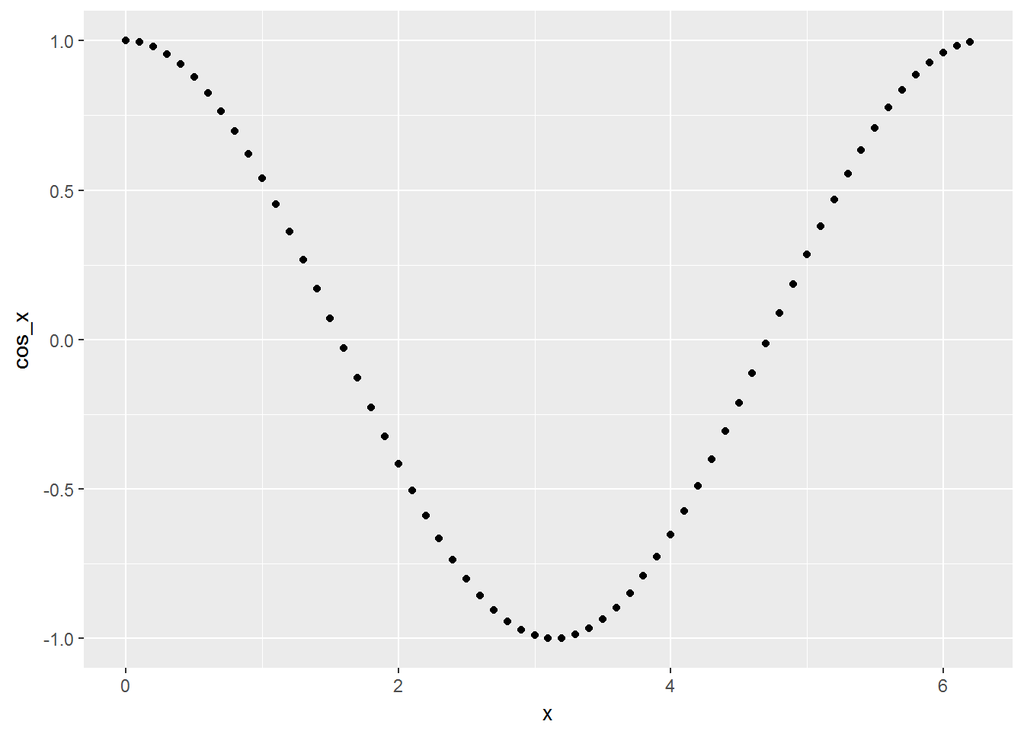

```r
cos_x <- cos(x)
qplot(x = x, y = cos_x)
```

To get both in the same plot, one way is to add a second layer.

To do that, we will need to dive deeper into ggplot2 than the qplot function, and use geom_point directly. Don’t forget to wrap the mappings with the aes function.

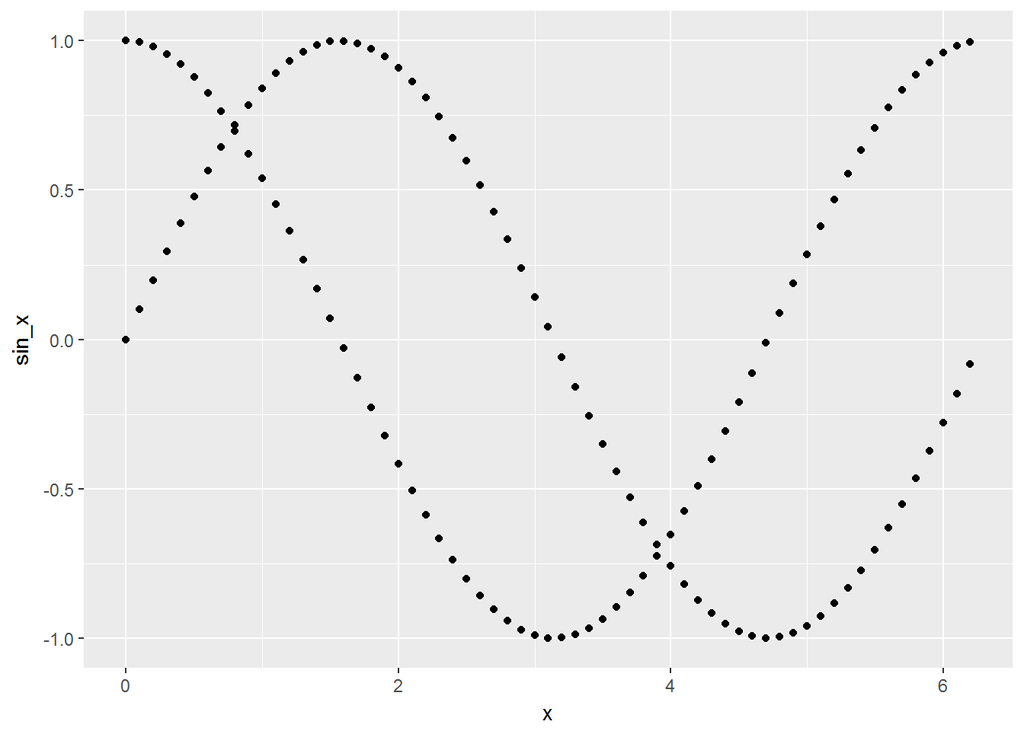

```r
sine_plot + geom_point(aes(x = x, y = cos_x))
```

This can also be written entirely without qplot:

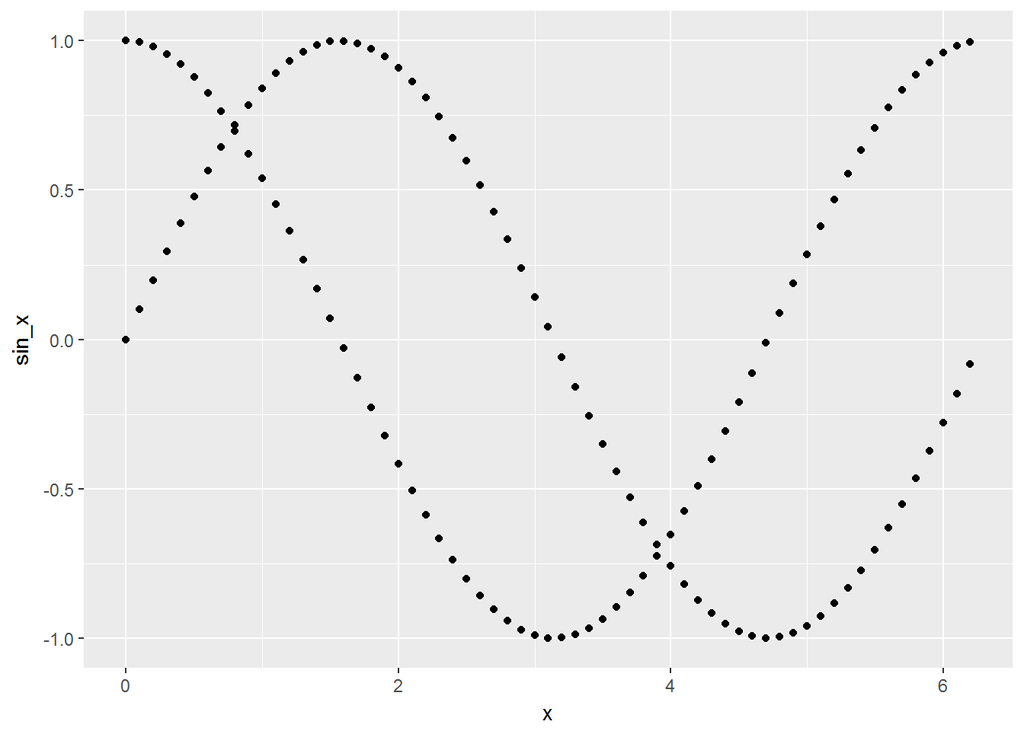

```r
ggplot() + geom_point(aes(x = x, y = sin_x)) + geom_point(aes(x = x, y = cos_x))
```

# 6

Source the script with the two functions:

```r
source("coin_toss.R")
```

Now, the functions exist in your R environment:

```r
sim_data
```

```
## function (nsim = 20)
## {
##     sample(c("h", "t"), nsim, replace = TRUE)
## }
```

```r
runs
```

```
## function (tosses)
## {
##     runs <- numeric(length(tosses))
##     runs[1] <- 1
##     j <- 1
##     for (i in 2:length(tosses)) {
##         if (tosses[i] == tosses[i - 1]) {
##             runs[j] <- runs[j] + 1
##         }
##         else {
##             j <- j + 1
##             runs[j] <- 1
##         }
##     }
##     runs[1:j]
## }
```

We can simulate some tosses:

```r
sim_data()
```

```
##  [1] "t" "t" "h" "h" "h" "t" "t" "t" "h" "h" "t" "t" "t" "t" "h" "t" "h"
## [18] "t" "h" "h"
```

```r
sim_data()
```

```
##  [1] "t" "t" "t" "t" "t" "h" "t" "h" "h" "t" "h" "t" "h" "h" "h" "t" "t"
## [18] "h" "h" "t"
```

Tabulate the random outcomes:

```r
table(sim_data())
```

```
##
##  h  t
##  8 12
```

```r
table(sim_data())
```

```
##
##  h  t
## 10 10
```

Or combine with a test:

```r
prop.test(table(sim_data()))
```

```
##
##  1-sample proportions test with continuity correction
##
## data:  table(sim_data()), null probability 0.5
## X-squared = 4.05, df = 1, p-value = 0.04417
## alternative hypothesis: true p is not equal to 0.5
## 95 percent confidence interval:
##  0.5058845 0.9040674
## sample estimates:
##    p
## 0.75
```

```r
prop.test(table(sim_data()))
```

```
##
##  1-sample proportions test with continuity correction
##
## data:  table(sim_data()), null probability 0.5
## X-squared = 0.45, df = 1, p-value = 0.5023
## alternative hypothesis: true p is not equal to 0.5
## 95 percent confidence interval:
##  0.1997709 0.6358833
## sample estimates:
##   p
## 0.4
```

```r
prop.test(table(sim_data()))
```

```
##
##  1-sample proportions test without continuity correction
##
## data:  table(sim_data()), null probability 0.5
## X-squared = 0, df = 1, p-value = 1
## alternative hypothesis: true p is not equal to 0.5
## 95 percent confidence interval:
##  0.299298 0.700702
## sample estimates:
##   p
## 0.5
```

Try the runs function:

```r
toss <- sim_data()
toss
```

```
##  [1] "h" "t" "h" "t" "h" "h" "h" "h" "h" "h" "h" "h" "h" "t" "t" "t" "t"
## [18] "t" "h" "h"
```

```r
runs(toss)
```

```
## [1] 1 1 1 1 9 5 2
```

And find the biggest value:

```r
max(runs(sim_data(10000)))
```

```
## [1] 17
```

```r
max(runs(sim_data(10000)))
```

```
## [1] 12
```

```r
max(runs(sim_data(10000)))
```

```
## [1] 13
```

# 7

```r
v <- c(1, 2, 1)
w <- c(2, 2, 2)
```

Elementwise multiplication:

```r
v*w
```

```
## [1] 2 4 2
```

To get the dot product, we use the %*% operator instead. It is used for matrix multiplication.

```r
v %*% w
```

```
##      [,1]
## [1,]    8
```

The number is right, but that was actuallya 1 x 1 matrix.

We can use drop to simplify it:

```r
drop(v %*% w)
```

```
## [1] 8
```

As per the definition of the dot product, we get the same by summing the results of elementwise multiplication:

```r
sum(v * w)
```

```
## [1] 8
```